# Method of weighted residuals

Given the differential equation $$ \frac{d}{dt}\left[x\frac{du}{dx}\right] = \frac{2}{x^2}$$ Boundary conditions $$u(1)=2$$ and $$-x\frac{du}{dx}\Biggr|_{x=2} = \frac{1}{2}$$ Assuming the trial function as $$ u_{h}(x)=a_{0}+a_{1}x+a_{2}x^{2}+\dots +a_{n}x^{n} $$ Considering the first four terms only $$ u^\sim_{h}(x)=a_{0}+a_{1}x+a_{2}x^{2}+a_{3}x^{3} $$ Using boundary condition 1, we have $$a_{0}+a_{1}+a_{2}+a_{3}=2$$ Using boundary condition 2, we have $$a_{1}+4a_{2}+12a_{3} = -\frac{1}{4}$$ Substituting the above to results in the trial function $$u^\sim_{h}(x)=2 - \frac{1}{4}(x-1)+a_{2}(x-1)(x-3)+a_{3}(x-1)(x^2+x-11)$$ In order to get the residual, R we substitute our trial function in the given differential equation $$ R = \frac{d}{dt}\left[x\frac{du}{dx}\right] - \frac{2}{x^2}$$ $$ \frac{du}{dx} = \dfrac{12 a_3 x^2+8a_2x-48a_3-16a_2-1}{4}$$ $$ R = \dfrac{36 a_3x^2+16a_2x-48a_3-16a_2-1}{4} - \frac{2}{x^2}$$

## Exact Solution

We obtain the following by integrating twice the given differential equation $$ u(x) = \frac{2}{x}+c_1lnx+c_2$$ Finding values of the integration constants and putting them back $$ u = \frac{2}{x}+\frac{lnx}{2}$$

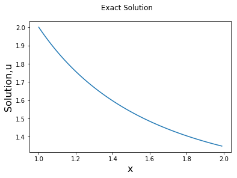

```python
import matplotlib.pyplot as plt
import numpy as np

x = np.arange(1, 2, 0.01)
#  expression for exact solution
u_exact = (2/x)+0.5*np.log(x)

plt.plot(x, u_exact)
plt.xlabel('x', fontsize=16)
plt.ylabel('Solution,u', fontsize=16)
plt.suptitle('Exact Solution')
plt.show()
```

## Collocation Method

In the collocation method, we force the residual to be zero at ${\displaystyle n}$ points ${\displaystyle x_{1},x_{2},\dots ,x_{n}}$ within the domain.That is $$R(x_1,a)= 0$$ $$R(x_2,a)=0$$ $$a = [a_1,a_2]$$ From the above equation we will get the value of $a$, and solution can be obtained by substituting it back in our trial function. For our problem, the domain of interest is ${\displaystyle 1\leq x\leq 2}$. Let us pick two points in this domain ${\displaystyle x_{1}}$ and ${\displaystyle x_{2}}$ such that ${\displaystyle 1\leq x_{1}<x_{2}\leq 2}$. In this example we choose ${\displaystyle x_{1}=4/3}$ and ${\displaystyle x_{2}=5/3}$.

[figure not shown]

```
eqn [1.33333333333333*a + 4.0*b - 1.375, 2.66666666666667*a + 13.0*b - 0.97]
a  2.09925000000000
b  -0.356000000000000
```

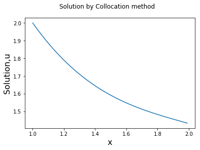

```python
import matplotlib.pyplot as plt
import numpy as np
from sympy import *

a_col = Symbol('a')
b_col = Symbol('b')
val_col = [4/3 ,5/3]
eqn_col =[]

def function(x):
	for x in val_col:
		# calculating residuals
		eqn_col.append(-0.25+4*(x-1)*a_col+3*(3*(x**2)-4)*b_col-(2/(x**2)))
	return(eqn_col)

solve(function(val_col), [a_col,b_col])
print("eqn",eqn_col)

z_col = solve(function(val_col), [a_col,b_col])
print("a ",z.get(a_col))
print("b ",z.get(b_col))

x = np.arange(1, 2, 0.01)
u_col = 2. - (0.25)*(x-1)+(x-1)*(x-3)*z_col.get(a_col)+(x-1)*(x**2+x-11)*z_col.get(b_col)
plt.plot(x, u_col)
plt.xlabel('x', fontsize=16)
plt.ylabel('Solution,u', fontsize=16)
plt.suptitle('Solution by Collocation method')
plt.show()
```

## Subdomain Method

```
a -0.327956989247312
b 0.120669056152927
```

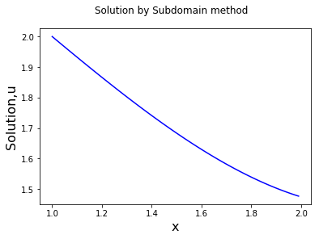

```python
from sympy import *
import matplotlib.pyplot as plt
import numpy as np
import matplotlib.patches as mpatches

a_sub = Symbol('a')
b_sub = Symbol('b')
x_sub = Symbol('x_sub')
eqn_sub =[]
eqn_sub.append(integrate(-0.25+4*(-1)*a_sub+3*(3*(x_sub**2)-4)*b_sub-(2/(x_sub**2)), (x_sub, 1, 1.5)))
eqn_sub.append(integrate(-0.25+4*(x_sub-1)*a_sub+3*(3*(x_sub**2)-4)*b_sub-(2/(x_sub**2)), (x_sub, 1.5, 2)))
z_sub = solve(eqn_sub, [a_sub,b_sub])
print("a",z_sub.get(a_sub))
print("b",z_sub.get(b_sub))
x_sub = np.arange(1, 2., 0.01)
u_sub = 2 - 0.25*(x_sub-1)+(x_sub-1)*(x_sub-3)*z_sub.get(a_sub)+(x_sub-1)*(x_sub**2+x_sub-11)*z_sub.get(b_sub)

plt.plot(x_sub, u_sub , color='b', label="Subdomain")
plt.xlabel('x', fontsize=16)
plt.ylabel('Solution,u', fontsize=16)
plt.suptitle('Solution by Subdomain method')
plt.show()
```

## Galerkin Method

```
4*x - 4
[3.33333333333333*a + 15.75*b - 2.0*log(2) - 0.375, 5.66666666666667*a + 27.8*b - 2.58333333333333]
```

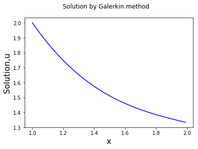

```python
from sympy import *
import matplotlib.pyplot as plt
import numpy as np
import matplotlib.patches as mpatches

a_gal = Symbol('a')
b_gal = Symbol('b')
x_gal = Symbol('x')
eqn_gal =[]
r_gal = -0.25+4*(x_gal-1)*a_gal+3*(3*(x_gal**2)-4)*b_gal-(2/(x_gal**2))
print(diff(r_gal,a_gal))
eqn_gal.append(integrate(r_gal*x_gal, (x_gal, 1, 2)))
eqn_gal.append(integrate(r_gal*x_gal*x_gal, (x_gal, 1, 2)))
print(eqn_gal)
z_gal = solve(eqn_gal, [a_gal,b_gal])

x = np.arange(1, 2., 0.01)
u_gal = 2 - 0.25*(x-1)+(x-1)*(x-3)*z_gal.get(a_gal)+(x-1)*((x**2)+x-11)*z_gal.get(b_gal)
plt.plot(x, u_gal , color='b')
plt.xlabel('x', fontsize=16)
plt.ylabel('Solution,u', fontsize=16)
plt.suptitle('Solution by Galerkin method')

plt.show()
```

## Least Squares Method

[output not shown]

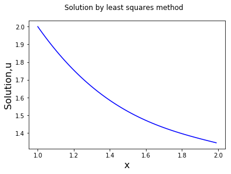

```python
from sympy import *
import matplotlib.pyplot as plt
import numpy as np
import matplotlib.patches as mpatches

a_lea = Symbol('a')
b_lea = Symbol('b')
x_lea = Symbol('x')
eqn_lea =[]
r_lea = -0.25+4*(x_lea-1)*a_lea+3*(3*(x_lea**2)-4)*b_lea-(2/(x_lea**2))
print(diff(r_lea,a_lea))
eqn_lea.append(integrate(r_lea*diff(r_lea,a_lea), (x_lea, 1, 2)))
eqn_lea.append(integrate(r_lea*diff(r_lea,b_lea), (x_lea, 1, 2)))
print(eqn_lea)
z_lea = solve(eqn_lea, [a_lea,b_lea])
print("a",z.get(a))
print("b",z.get(b))
x = np.arange(1, 2., 0.01)
u_lea = 2 - 0.25*(x-1)+(x-1)*(x-3)*z_lea.get(a_lea)+(x-1)*((x**2)+x-11)*z_lea.get(b_lea)
plt.plot(x, u_lea , color='b')
plt.xlabel('x', fontsize=16)
plt.ylabel('Solution,u', fontsize=16)
plt.suptitle('Solution by least squares method')
plt.show()
```

## Comparision

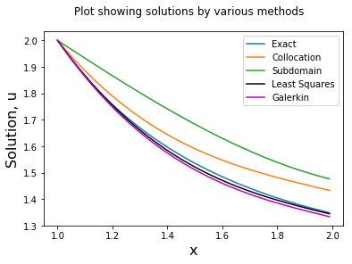

```python
import matplotlib.pyplot as plt
import numpy as np
from sympy import *
############################# col
a_col = Symbol('a')
b_col = Symbol('b')
val_col = [4/3 ,5/3]
eqn_col =[]

def function(x):
	for x in val_col:
		# calculating residuals
		eqn_col.append(-0.25+4*(x-1)*a_col+3*(3*(x**2)-4)*b_col-(2/(x**2)))
	return(eqn_col)

z_col = solve(function(val_col), [a_col,b_col])
############################# sub
a_sub = Symbol('a')
b_sub = Symbol('b')
x_sub = Symbol('x_sub')
eqn_sub =[]
eqn_sub.append(integrate(-0.25+4*(-1)*a_sub+3*(3*(x_sub**2)-4)*b_sub-(2/(x_sub**2)), (x_sub, 1, 1.5)))
eqn_sub.append(integrate(-0.25+4*(x_sub-1)*a_sub+3*(3*(x_sub**2)-4)*b_sub-(2/(x_sub**2)), (x_sub, 1.5, 2)))
z_sub = solve(eqn_sub, [a_sub,b_sub])

############################# least square
a_lea = Symbol('a')
b_lea = Symbol('b')
x_lea = Symbol('x')
eqn_lea =[]
r_lea = -0.25+4*(x_lea-1)*a_lea+3*(3*(x_lea**2)-4)*b_lea-(2/(x_lea**2))
eqn_lea.append(integrate(r_lea*diff(r_lea,a_lea), (x_lea, 1, 2)))
eqn_lea.append(integrate(r_lea*diff(r_lea,b_lea), (x_lea, 1, 2)))
z_lea = solve(eqn_lea, [a_lea,b_lea])
############################# galerian method
a_gal = Symbol('a')
b_gal = Symbol('b')
x_gal = Symbol('x')
eqn_gal =[]
r_gal = -0.25+4*(x_gal-1)*a_gal+3*(3*(x_gal**2)-4)*b_gal-(2/(x_gal**2))
eqn_gal.append(integrate(r_gal*x_gal, (x_gal, 1, 2)))
eqn_gal.append(integrate(r_gal*x_gal*x_gal, (x_gal, 1, 2)))
z_gal = solve(eqn_gal, [a_gal,b_gal])
############################# method end

x = np.arange(1, 2, 0.01)

u_col = 2. - (0.25)*(x-1)+(x-1)*(x-3)*z_col.get(a_col)+(x-1)*(x**2+x-11)*z_col.get(b_col)
u_exact = (2/x)+0.5*np.log(x)
u_sub = 2 - 0.25*(x-1)+(x-1)*(x-3)*z_sub.get(a_sub)+(x-1)*(x**2+x-11)*z_sub.get(b_sub)
u_lea = 2 - 0.25*(x-1)+(x-1)*(x-3)*z_lea.get(a_lea)+(x-1)*((x**2)+x-11)*z_lea.get(b_lea)
u_gal = 2 - 0.25*(x-1)+(x-1)*(x-3)*z_gal.get(a_gal)+(x-1)*((x**2)+x-11)*z_gal.get(b_gal)

plt.plot(x, u_exact, label="Exact")
plt.plot(x, u_col, label="Collocation")
plt.plot(x, u_sub, label="Subdomain")
plt.plot(x, u_lea, label="Least Squares", color="black")
plt.plot(x, u_gal, label="Galerkin", color ="m")

plt.legend()
plt.xlabel('x', fontsize=16)
plt.ylabel('Solution, u', fontsize=16)
plt.suptitle('Plot showing solutions by various methods')
plt.show()
```